# Shubham Zod_38A_RTSM_Time Series Analysis_CEAT LTD Stock price analysis

```r
#REQUIRED PACKAGES
packages = c('tseries','forecast','quantmod','car','FinTS','rugarch')

#Load all packages
lapply(packages, require, character.only = TRUE)
```

```
[[1]]
[1] TRUE

[[2]]
[1] TRUE

[[3]]
[1] TRUE

[[4]]
[1] TRUE

[[5]]
[1] TRUE

[[6]]
[1] TRUE
```

```r
#lapply(quantmod)
```

```r
stock_data = new.env()
stock_list = c('CEATLTD.NS')
start_date = as.Date('2015-01-01'); end_date = as.Date('2019-12-31')
getSymbols(Symbols = stock_list, from = start_date, to = end_date, env = stock_data)
```

```
[1] "CEATLTD.NS"
```

```r
stock_price=na.omit(stock_data$CEATLTD.NS$CEATLTD.NS.Adjusted)
#ceat_price

#stock_price = CEATLTD.NS$CEATLTD.NS.Close # Adjusted Closing Price
class(stock_price) # xts (Time-Series) Object
```

```
[1] "xts" "zoo"
```

```r
stock_price
```

```
           CEATLTD.NS.Adjusted
2015-01-01            798.2305
2015-01-02            805.4606
2015-01-05            803.9962
2015-01-06            775.7626
2015-01-07            779.1946
2015-01-08            794.2494
2015-01-09            789.1702
2015-01-12            788.9871
2015-01-13            794.4782
2015-01-14            778.0047
       ...
2019-12-16            947.3059
2019-12-17            953.4615
2019-12-18            949.9990
2019-12-19            952.8845
2019-12-20            953.9426
2019-12-23            958.7516
2019-12-24            961.8776
2019-12-26            949.3257
2019-12-27            968.9471
2019-12-30            955.2410
```

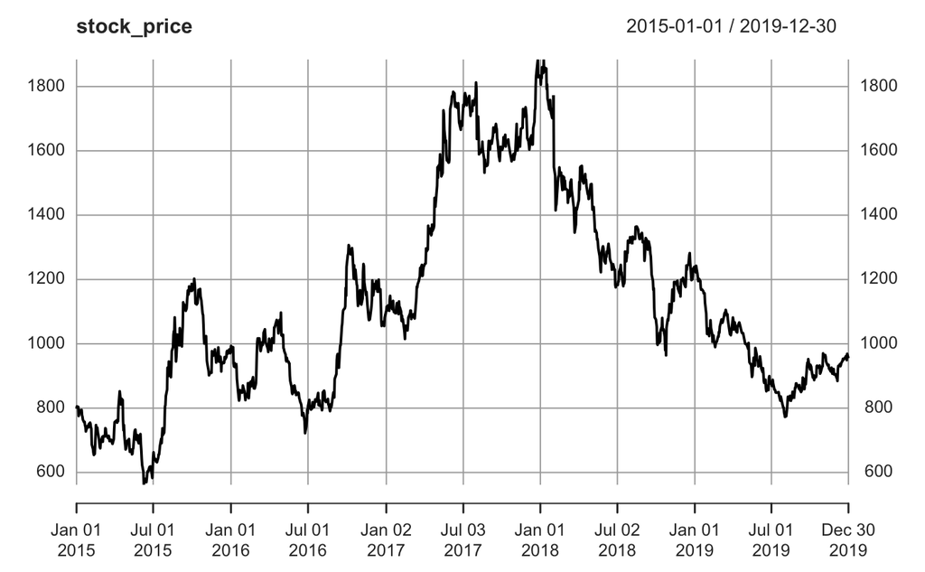

```r
plot(stock_price)
```

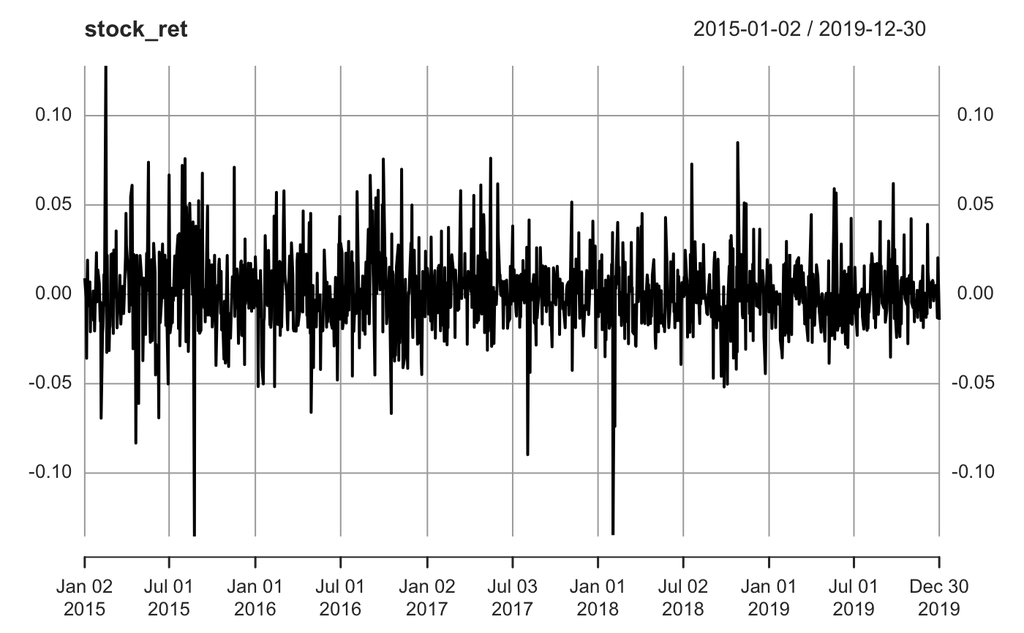

```r
stock_ret = na.omit(diff(log(stock_price))) # Stock Returns
plot(stock_ret)
```

```r
# Required Packages
packages = c('tseries', 'forecast')

# Load all Packages
lapply(packages, require, character.only = TRUE)
```

```
[[1]]
[1] TRUE

[[2]]
[1] TRUE
```

```r
# ---------------------------------------------------------------------------------------------

# Forecasting with Time-Series Data (Univariate) : Procedure
# **********************************************************

# Given an Univariate Time-Series Data, Perform the following Analysis :

# Step 1 : Check for (Weak) Stationarity :: Augmented Dickey-Fuller (ADF) Test
# If [Data] Stationary, Proceed to Step 2
# If [Data] Non-Stationary, Use Transformation (such as First/Second/... Difference | Log | ...) to Transform the Data and Check for Stationarity (Step 1)

# Step 2 : Check for Autocorrelation :: Ljung-Box Test
# If [Data | Transformed Data] Do Not Have Autocorrelation, proceed to Step 4
# If [Data | Transformed Data] Has Autocorrelation, Proceed to Step 3

# Step 3 : Model for Autocorrelation :: ARIMA Models
# Identify AR | MA Order in the [Data | Transformed Data] using PACF | ACF Plots
# Use ARIMA(p, d, q) with Appropriate AR Order (p-Lags) | d-Degree of Differencing | MA Order (q-Lags) using PACF | ACF Information to Model the [Data | Transformed Data]
# Test for Autocorrelation in the [Residual Data 1] | If the ARIMA Model is Appropriate : No Autocorrelation in the [Residual Data 1] | If Autocorrelation in [Residual Data 1], Remodel the [Data | Transformed Data]
# Proceed to Step 4

# Step 4 : Check for Heteroskedasticity :: ARCH LM Test
# If [Data | Transformed Data] (Step 2) | [Residual Data 1] (Step 3) Do Not Have Heteroskedasticity, Proceed to Step 6
# If [Data | Transformed Data] (Step 2) | [Residual Data 1] (Step 3) Has Heteroskedasticity, Proceed to Step 5

# Step 5a : Model for Heteroskedasticity in [Data | Transformed Data] (Step 2) :: GARCH Models
# If Mean of [Data | Transformed Data] (Step 2) != 0 : De-Mean & Square the [Data | Transformed Data] | If Mean of [Data | Transformed Data] (Step 2) = 0 : Square the [Data | Transformed Data]
# Identify ARCH | GARCH Order in the using GARCH Function
# Use GARCH(p,q) with Appropriate ARCH Order (p-Lags) | GARCH Order (q-Lags) to Model the [Data | Transformed Data]
# Test for Autocorrelation & Heteroskedasticity in the [Residual Data 2] | If the GARCH Model is Appropriate : No Autocorrelation & Heteroskedasticity in the [Residual Data 2] | If Autocorrelation & Heteroskedasticity in [Residual Data 2], Remodel the Squared [Data | Transformed Data]
# End of Analysis

# Step 5b : Model for Heteroskedasticity in [Residual Data 1] (Step 3) :: GARCH Models
# Identify ARCH | GARCH Order in the using GARCH Function
# Use GARCH(p, q) with Appropriate ARCH Order (p-Lags) | GARCH Order (q-Lags) with ARIMA(p, d, q) Model (in Step 3) in the Mean Equation to Model the [Residual Data 1]
# Test for Autocorrelation & Heteroskedasticity in the [Residual Data 2] | If the ARIMA+GARCH Model is Appropriate : No Autocorrelation & Heteroskedasticity in the [Residual Data 2] | If Autocorrelation & Heteroskedasticity in [Residual Data 2], Remodel the [Residual Data 1]
# End of Analysis

# Step 6 : Model White-Noise Data
# If the [Data | Transformed Data] is Stationary, Has No Autocorrelation & Heteroskedasticity, the [Data | Transformed Data] is White-Noise Data
# Model White-Noise Data with Appropriate Probability Distribution
# End of Analysis
```

```r
# Augmented Dickey-Fuller (ADF) Test for Stationarity with CEAT Data
# *******************************************************************

adf_test_ceat = adf.test(stock_price);adf_test_ceat
```

```
    Augmented Dickey-Fuller Test

data:  stock_price
Dickey-Fuller = -1.4851, Lag order = 10, p-value = 0.7963
alternative hypothesis: stationary
```

```r
# Inference : ceat Time-Series is Non-Stationary
```

ANALYSIS:

The output of the Augmented Dickey-Fuller (ADF) test on the CEAT stock price data suggests the following:

Test Statistic: The Dickey-Fuller test statistic is -1.4851. Lag Order: The test was performed with a lag order of 10. p-value: The p-value obtained from the test is 0.7963. Based on the p-value obtained, which is significantly greater than the typical significance level of 0.05, there is insufficient evidence to reject the null hypothesis. The null hypothesis of the ADF test is that the time series data is non-stationary. Therefore, we cannot conclude that the CEAT stock price data is stationary.